# Data visualization with ggplot2

# Combining multiple ggplot objects

In base R, “par(mfrow=c( , ))” is a very nice, quick way to display multiple plots on a single page. This does NOT work for ggplot plots. Happily, there are several ways around this:

- Facets

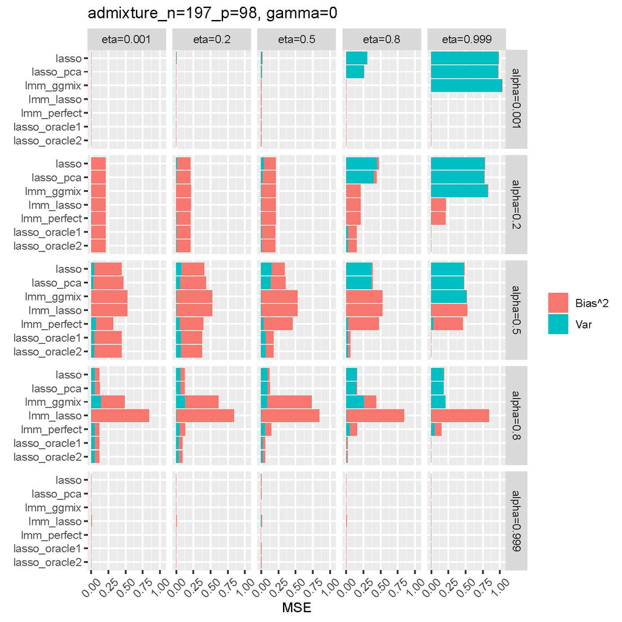

Facet example

- Packages
  - [gridExtra](https://cran.r-project.org/web/packages/gridExtra/vignettes/arrangeGrob.html/)
  - [cowplot](https://cran.r-project.org/web/packages/cowplot/vignettes/introduction.html)
  - [egg](https://cran.r-project.org/web/packages/egg/vignettes/Overview.html)

The basic idea for gridExtra/cowplot/egg is to divide up the plotting space using a grid and to plot the ggplot objects accordingly. I’ll leave the details to these references.

# Special characters in titles and labels

We can include greek letters and sub/superscripts by putting our title in an expression.

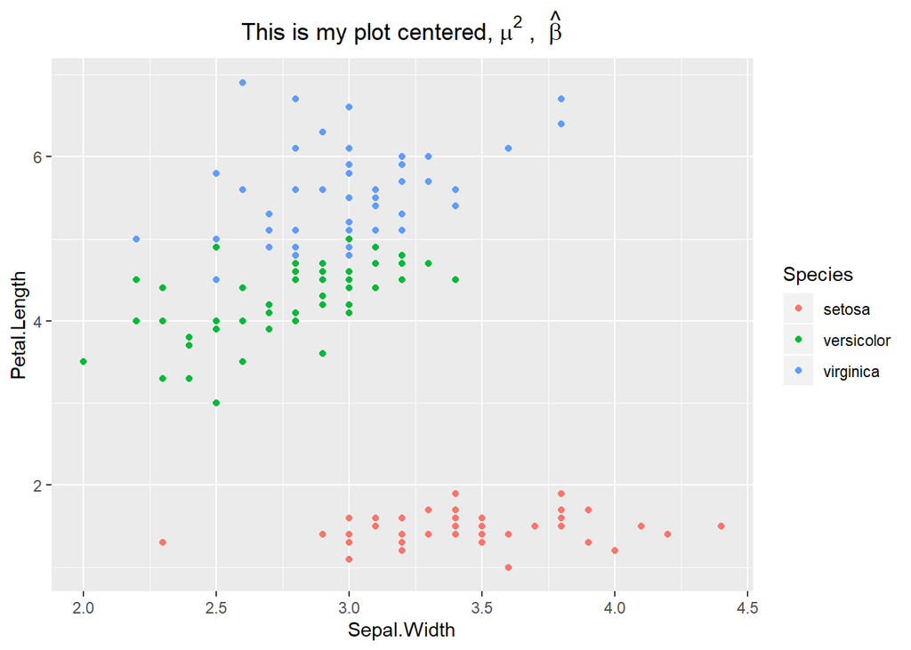

```r
g4 <- ggplot(iris, aes(Sepal.Width, Petal.Length, colour = Species)) +
          geom_point() +
          ggtitle(expression("This is my plot centered,"~mu^2~", "~hat(beta))) +
          theme(plot.title = element_text(hjust = 0.5))

print(g4)
```

Or, if we want Greek letters, sub/super scripts along with variables, we need to use bquote.

```r
# what's the correlation between Petal.Length and Sepal.Width?
myCor <- cor(iris$Petal.Length, iris$Sepal.Width)
myCor # let's round this or it'll all print...
```

```
## [1] -0.4284401
```

```r
myCor <- round(myCor, digits = 2)
myCor
```

```
## [1] -0.43
```

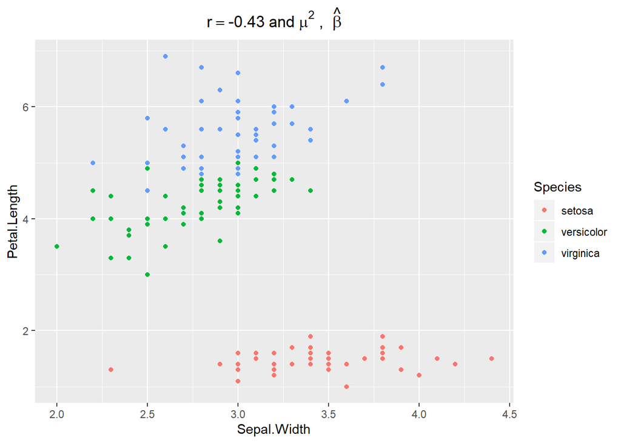

```r
g4 <- ggplot(iris, aes(Sepal.Width, Petal.Length, colour = Species)) +
          geom_point() +
          ggtitle(bquote("r" == .(myCor)~"and"~mu^2~", "~hat(beta))) +
          theme(plot.title = element_text(hjust = 0.5))

print(g4)
```

[R-bloggers bquote reference](https://www.r-bloggers.com/math-notation-for-r-plot-titles-expression-and-bquote/)

# Creating ggplots within functions

bquote can be especially helpful when creating ggplots as function outputs. Instead of plotting all three species together, we could write a function to create a scatter plot for each one, with an appropriate title.

```r
myScatter <- function(df, subvar, sublevel, xvar, yvar){
  g_df <- df[which(df[, subvar] == sublevel),]
  g <- ggplot(g_df, aes(x=xvar, y=yvar)) +
       geom_point() +
       ggtitle(bquote("Species: "~.(sublevel)))
  return(g)
}

g <- myScatter(iris, "Species", "setosa", Sepal.Width, Petal.Length)
print(g)
# Error in FUN(X[[i]], ...) : object 'Sepal.Width' not found
```

What’s the problem with this?

Within the function, xvar and yvar resolve to Sepal.Width and Petal.Length respectively, which are not defined objects.

Similarly, the code below won’t give us what we want.

```r
g <- myScatter(iris, "Species", "setosa", "Sepal.Width", "Petal.Length")
print(g)
```

Instead, we need to include our x and y vars as strings and have ggplot map those strings to the variables we want in one of several ways.

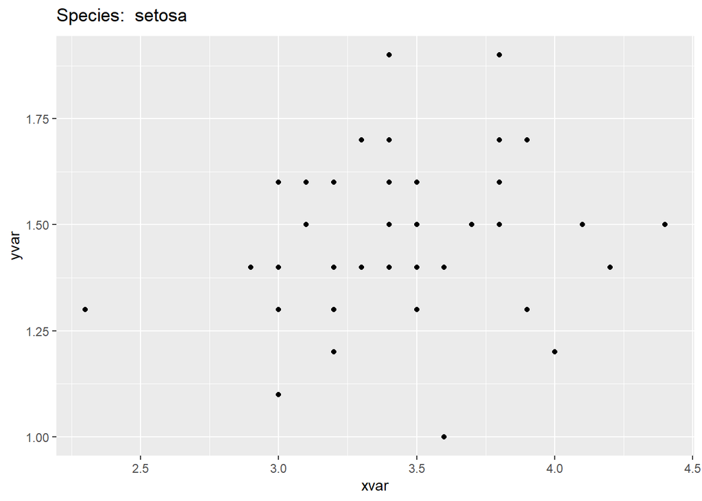

```r
### option 1
myScatter <- function(df, subvar, sublevel, xvar, yvar){
  g_df <- df[which(df[, subvar] == sublevel),]

  g_df$xvar <- g_df[, xvar] # just create vars named "xvar"
  g_df$yvar <- g_df[, yvar] # and "yvar"

  g <- ggplot(g_df, aes(x=xvar, y=yvar)) +
       geom_point() +
       ggtitle(bquote("Species: "~.(sublevel)))
  return(g)
}

g <- myScatter(iris, "Species", "setosa", "Sepal.Width", "Petal.Length")
print(g)
```

```r
### option 2
myScatter <- function(df, subvar, sublevel, xvar, yvar){
  g_df <- df[which(df[, subvar] == sublevel),]
  g <- ggplot(g_df, aes_string(x=xvar, y=yvar)) + # use aes_string, not aes
       geom_point() +
       ggtitle(bquote("Species: "~.(sublevel)))
  return(g)
}

g <- myScatter(iris, "Species", "setosa", "Sepal.Width", "Petal.Length")
print(g)
```

[output not shown]

```r
### option 3
myScatter <- function(df, subvar, sublevel, xvar, yvar){
  xvar <- sym(xvar) # sym converts the symbol to the string that the variable contains
  print(xvar)
  yvar <- sym(yvar)
  g_df <- df[which(df[, subvar] == sublevel),]
  g <- ggplot(g_df, aes(x=!!xvar, y=!!yvar)) +  # !! unquotes the string
       geom_point() +
       ggtitle(bquote("Species: "~.(sublevel)))
  return(g)
}

g <- myScatter(iris, "Species", "setosa", "Sepal.Width", "Petal.Length")
```

```
## Sepal.Width
```

```r
print(g)
```

[output not shown]

```r
### option 4
myScatter <- function(df, subvar, sublevel, xvar, yvar){
  xvar <- ensym(xvar) # sym converts the symbol to the string that the variable contains
  print(xvar)
  yvar <- ensym(yvar)
  g_df <- df[which(df[, subvar] == sublevel),]
  g <- ggplot(g_df, aes(x=!!xvar, y=!!yvar)) +  # !! unquotes the string
       geom_point() +
       ggtitle(bquote("Species: "~.(sublevel)))
  return(g)
}

g <- myScatter(iris, "Species", "setosa", "Sepal.Width", "Petal.Length")
```

```
## Sepal.Width
```

```r
print(g)
```

[output not shown]

Option 1 is admittedly hacky, and you’ll end up with the not-very-informative axes labels “xvar” and “yvar.” However it works consistently, and you can always pass informative labels in as characters.

Option 2 works well here, but in practice I have had this break a lot.

Options 3 and 4 are new as of V3.0.0 and so I admit I haven’t used them.

# Colors

- [R color brewer](https://www.datanovia.com/en/blog/the-a-z-of-rcolorbrewer-palette/#display-all-brewer-palettes) includes nice color palettes, as well as some specific to color-blind individuals.
- For more information on the ggplot2 default color scales, and how to customize color scales, see the [scales package](https://scales.r-lib.org/)
- A handy function for getting a vector of the default ggplot2 hex colors (which is just equally spaced hues around the color wheel, starting from 15) is the following:

```r
gg_color_hue <- function(n) {
  hues = seq(15, 375, length = n + 1)
  hcl(h = hues, l = 65, c = 100)[1:n]
}
```

(Thanks, [stackoverflow](https://stackoverflow.com/questions/8197559/emulate-ggplot2-default-color-palette).)

This is useful because it allows you to create non-ggplots that use the same color scheme as ggplots. It’s also handy if you have one plot with say, 5 colors, and then you want to only plot 3 of those colors, but you want them to be consistent across plots.

# Interactive ggplots: ggplotly

- [plotly/ggplotly](https://plotly-r.com/index.html)
- [Plotly Heatmap Example](http://myweb.uiowa.edu/pbreheny/clb/gTBFPSwBWfJFZzSyVKIw/metPan.html)

# Other Resources

- http://www.cookbook-r.com/Graphs/
- https://ggplot2.tidyverse.org/
- Google / StackOverflow
- [Old but helpful and well-illustrated reshape2 examples](https://seananderson.ca/2013/10/19/reshape)
- [Difference between reshape2 and tidyr](https://rpubs.com/sterding/Reshape2_and_Tidyr)